# Predicting How Participants Performed Physical Activities

Tejus Maduskar

November 10, 2018

This report is organized into the following key sections: (A.) Brief synopsis of the problem (B.) Loading the data and the required libraries (C.) Reviewing/exploring the data (D.) Cleaning the data (E.) Preparing the training and validation data (F.) Building and testing different models (G.) Conclusion and final model selection

## A. Synposis

Data credits: The data for this project assignment came from this website: http://groupware.les.inf.puc-rio.br/har

The submission consists of a link to a GitHub repo with an R markdown and compiled HTML file. The repo has a gh-pages branch to allow the HTML page to be viewed online.

## B. Loading the data and the required libraries

```r
library(rattle)
library(caret)
```

```r
pmlTraining <- read.csv(url("https://d396qusza40orc.cloudfront.net/predmachlearn/pml-training.csv"),header=TRUE)
pmlTesting <- read.csv(url("https://d396qusza40orc.cloudfront.net/predmachlearn/pml-testing.csv"),header=TRUE)
```

## C. Reviewing and exploring the data

```r
# str(pmlTraining)
```

From the output of the str() command (commented out to limit output HTML report to 5 pages), it is clear that several variables have a vast number of NA values, some variables may not have enough variability to be of use, and some variables contain data that may not be useful from a prediction perspective. All the variables that meet these criteria may be removed from the data frame.

## D. Cleaning the data

Determine how many variables have >50% of values as NAs

```r
sum(colSums(is.na(pmlTraining))/nrow(pmlTraining) > 0.5)    ## how many variables have > 50% NAs
```

```
## [1] 67
```

67 out of the 160 variables have NAs, and the proportion of NAs in each variable is > 50%. These variables are therefore removed from the data set. Also remove variables with blank values over 50%. In other words, retain only those variables which have < 50% of their values as NAs or blanks. Do the same test for the testing dataset.

```r
pmlTraining1 <- pmlTraining[, colSums(is.na(pmlTraining) | pmlTraining == "") < 0.5 * nrow(pmlTraining)]
pmlTesting1 <- pmlTesting[, colSums(is.na(pmlTesting) | pmlTesting == "") < 0.5 * nrow(pmlTesting)]
```

The cleaning steps, however, will not remove non-NA and non-blank variables that have near zero variability. Let’s find and remove such variables. First, let’s identify these variables.

```r
nzvTraining <- nearZeroVar(pmlTraining1)
pmlTraining2 <- pmlTraining1[, - nzvTraining]
names(pmlTraining2)
```

```
##  [1] "X"                    "user_name"            "raw_timestamp_part_1"
##  [4] "raw_timestamp_part_2" "cvtd_timestamp"       "num_window"
##  [7] "roll_belt"            "pitch_belt"           "yaw_belt"
## [10] "total_accel_belt"     "gyros_belt_x"         "gyros_belt_y"
## [13] "gyros_belt_z"         "accel_belt_x"         "accel_belt_y"
## [16] "accel_belt_z"         "magnet_belt_x"        "magnet_belt_y"
## [19] "magnet_belt_z"        "roll_arm"             "pitch_arm"
## [22] "yaw_arm"              "total_accel_arm"      "gyros_arm_x"
## [25] "gyros_arm_y"          "gyros_arm_z"          "accel_arm_x"
## [28] "accel_arm_y"          "accel_arm_z"          "magnet_arm_x"
## [31] "magnet_arm_y"         "magnet_arm_z"         "roll_dumbbell"
## [34] "pitch_dumbbell"       "yaw_dumbbell"         "total_accel_dumbbell"
## [37] "gyros_dumbbell_x"     "gyros_dumbbell_y"     "gyros_dumbbell_z"
## [40] "accel_dumbbell_x"     "accel_dumbbell_y"     "accel_dumbbell_z"
## [43] "magnet_dumbbell_x"    "magnet_dumbbell_y"    "magnet_dumbbell_z"
## [46] "roll_forearm"         "pitch_forearm"        "yaw_forearm"
## [49] "total_accel_forearm"  "gyros_forearm_x"      "gyros_forearm_y"
## [52] "gyros_forearm_z"      "accel_forearm_x"      "accel_forearm_y"
## [55] "accel_forearm_z"      "magnet_forearm_x"     "magnet_forearm_y"
## [58] "magnet_forearm_z"     "classe"
```

```r
nzvTesting <- nearZeroVar(pmlTesting1)
pmlTesting2 <- pmlTesting1[, - nzvTesting]
names(pmlTesting2)
```

```
##  [1] "X"                    "user_name"            "raw_timestamp_part_1"
##  [4] "raw_timestamp_part_2" "cvtd_timestamp"       "num_window"
##  [7] "roll_belt"            "pitch_belt"           "yaw_belt"
## [10] "total_accel_belt"     "gyros_belt_x"         "gyros_belt_y"
## [13] "gyros_belt_z"         "accel_belt_x"         "accel_belt_y"
## [16] "accel_belt_z"         "magnet_belt_x"        "magnet_belt_y"
## [19] "magnet_belt_z"        "roll_arm"             "pitch_arm"
## [22] "yaw_arm"              "total_accel_arm"      "gyros_arm_x"
## [25] "gyros_arm_y"          "gyros_arm_z"          "accel_arm_x"
## [28] "accel_arm_y"          "accel_arm_z"          "magnet_arm_x"
## [31] "magnet_arm_y"         "magnet_arm_z"         "roll_dumbbell"
## [34] "pitch_dumbbell"       "yaw_dumbbell"         "total_accel_dumbbell"
## [37] "gyros_dumbbell_x"     "gyros_dumbbell_y"     "gyros_dumbbell_z"
## [40] "accel_dumbbell_x"     "accel_dumbbell_y"     "accel_dumbbell_z"
## [43] "magnet_dumbbell_x"    "magnet_dumbbell_y"    "magnet_dumbbell_z"
## [46] "roll_forearm"         "pitch_forearm"        "yaw_forearm"
## [49] "total_accel_forearm"  "gyros_forearm_x"      "gyros_forearm_y"
## [52] "gyros_forearm_z"      "accel_forearm_x"      "accel_forearm_y"
## [55] "accel_forearm_z"      "magnet_forearm_x"     "magnet_forearm_y"
## [58] "magnet_forearm_z"     "problem_id"
```

Also from str() commands, it is clear that the values in the first 6 variables don’t seem to have meaningful impact on the outcome, “classe”, and therefore these variables could be removed from the training and testing sets.

```r
pmlTraining3 <- pmlTraining2[, -c(1:6)]
pmlTesting3 <- pmlTesting2[, -c(1:6)]
```

Both training and test datasets now have the exact same variables remaining.

## E. Preparing the training and validation data

Let’s split the training set into a new training and validation set. Also, rename test data.

```r
pmlTesting <- pmlTesting3
set.seed(11111)
splitTraining <- createDataPartition(y=pmlTraining3$classe, p=0.7, list=FALSE)
pmlTraining <- pmlTraining3[splitTraining, ]
pmlValidation <- pmlTraining3[-splitTraining, ]
dim(pmlTraining)
```

```
## [1] 13737    53
```

```r
dim(pmlValidation)
```

```
## [1] 5885   53
```

## F. Building and testing different models

Let’s test three different models, using cross-validation with 5 folds: 1. Classification trees 2. Random forest 3. Gradient boosting method

First, set the train-control parameter

```r
trControl <- trainControl(method="cv", number=5)
```

1. Let’s try the classification tree modeling technique first: Train the model.

```r
modFitCT <- train(classe ~ ., data=pmlTraining, method="rpart", trControl=trControl)
modFitCT$finalModel
```

```
## n= 13737
##
## node), split, n, loss, yval, (yprob)
##       * denotes terminal node
##
##  1) root 13737 9831 A (0.28 0.19 0.17 0.16 0.18)
##    2) roll_belt< 130.5 12587 8693 A (0.31 0.21 0.19 0.18 0.11)
##      4) pitch_forearm< -33.35 1118   10 A (0.99 0.0089 0 0 0) *
##      5) pitch_forearm>=-33.35 11469 8683 A (0.24 0.23 0.21 0.2 0.12)
##       10) magnet_dumbbell_y< 438.5 9692 6964 A (0.28 0.18 0.24 0.19 0.11)
##         20) roll_forearm< 121.5 6015 3556 A (0.41 0.18 0.19 0.17 0.059) *
##         21) roll_forearm>=121.5 3677 2479 C (0.073 0.18 0.33 0.23 0.19) *
##       11) magnet_dumbbell_y>=438.5 1777  872 B (0.033 0.51 0.044 0.22 0.19) *
##    3) roll_belt>=130.5 1150   12 E (0.01 0 0 0 0.99) *
```

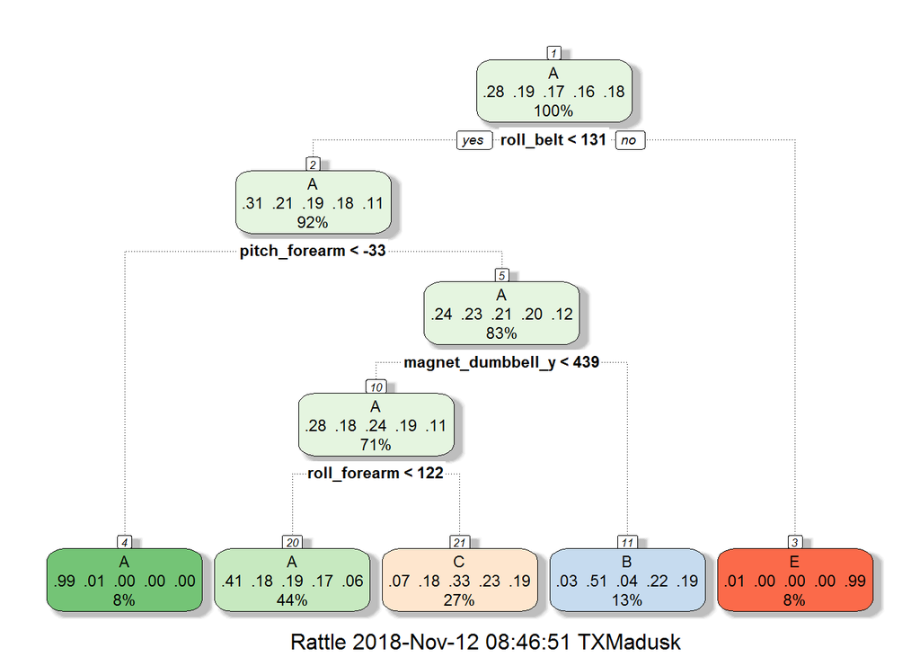

```r
fancyRpartPlot(modFitCT$finalModel)
```

Predict with this model on the validation set.

```r
predCT <- predict(modFitCT, newdata=pmlValidation)
```

Calculate the accuracy of predicted model vs. actual observations in the validation set.

```r
confusionMatrix(predCT, pmlValidation$classe)$overall[1]
```

```
##  Accuracy
## 0.4953271
```

The accuracy is quite low, at 49.5%, which implies an out of sample error rate of 1 - 0.495% = 50.5%

2. Now let’s try the random forest modeling technique: Given the volume of data, random forest can take a significant amount of time, therefore we need to perform parallel processing to speed up the processing. This is based on the course discussion forum and the link to this article provided by course mentor, Leonard Greski, below: https://github.com/lgreski/datasciencectacontent/blob/master/markdown/pml-randomForestPerformance.md

The four steps involved in parallel processing are as follows. (1) Configure parallel processing

```r
library(parallel)
library(doParallel)
cluster <- makeCluster(detectCores() - 1)
registerDoParallel(cluster)
```

2. Configure trainControl object

```r
trControl <- trainControl(method = "cv", number = 5, allowParallel = TRUE)
```

In the above, we used 5-fold cross-validation.

3. Develop training model

```r
modFitRF1 <- train(classe ~ ., data=pmlTraining, method="rf", trControl=trControl, verbose=FALSE)
```

4. De-register parallel processing cluster

```r
stopCluster(cluster)
registerDoSEQ()
predRF <- predict(modFitRF1, newdata=pmlValidation)
confusionMatrix(predRF, pmlValidation$classe)$overall[1]
```

```
##  Accuracy
## 0.9937128
```

After processing we explicitly shut down the cluster by calling stopCluster() and registerDoSEQ() functions. The registerDoSEQ() function is required to force R to return to single threaded processing.

The accuracy is quite high, at 99.4%, which implies an out of sample error rate of 1 - 99.4% = 0.6%

3. Finally, let’s try the gradient boosting method (gbm) modeling technique: Once again, given the large amounts of time required to train the model using gbm, we will perform parallel processing to speed up the processing.

```r
cluster <- makeCluster(detectCores() - 1)
registerDoParallel(cluster)
trControl <- trainControl(method = "cv", number = 5, allowParallel = TRUE)
```

Develop the training model, and predict:

```r
modFitGBM <- train(classe ~ ., data=pmlTraining, method="gbm", trControl=trControl, verbose=FALSE)
stopCluster(cluster)
registerDoSEQ()
predGBM <- predict(modFitGBM, newdata=pmlValidation)
confusionMatrix(predGBM, pmlValidation$classe)$overall[1]
```

```
##  Accuracy
## 0.9643161
```

## G. Conclusion and Final Model Selection

Random forest (ModFitRF) has the highest accuracy, so we’ll use that to for final prediction on the test data set.

```r
finalPrediction <- predict(modFitRF1, newdata=pmlTesting)
finalPrediction
```

```
##  [1] B A B A A E D B A A B C B A E E A B B B
## Levels: A B C D E
```

```r
#stopCluster(cluster)    # added from RF
#registerDoSEQ()         # added from RF
```